# Alice in the Data Science World: A Tale Through the Lens of Radar Chart

Welcome to the Wonderland of Data Science!

Our analysis uses data from 20,036 responses in the Kaggle’s 2020 survey. Although the survey is limited to the Kaggle community, we believe the insights about these Kagglers will not only apply to our community, but also generalize to a larger data science community in which we better understand the roadmap that people are taking, the tools that people are developing, and the language that people are using to communicate about data science nowadays. We decide to tell our story by means of radar chart as we want to focus on the behavioral tendencies of the respondents and compare the trends between different detected groups of data scientists within the Kaggle community.

Just like Alice going on an adventure to the Wonderland, no matter where you are on the data science path, you will definitely “grow up” and survive in this confusing yet very exciting world. We hope our analysis will serve as a guide for you to master the arts of data science and help you stay up to date with the latest trends in the field. Now, let’s get started!

# Method

In this analysis, we aim to detect different groups of data scientists within the Kaggle community using clustering technique. Questions 1, 2, 3, 4, 6, and 15 are selected as input features for clustering since demographics, education, and years of experience are all fixed properties representative of an indivdual. The input questions are as below:

- Q1: What is your age (#years)?
- Q2: What is your gender?
- Q3: In which country do you currently reside?
- Q4: What is the highest level of formal education that you have attained or plan to attain within the next 2 years?
- Q6: For how many years have you been writing code and/or programming?
- Q15: For how many years have you used machine learning methods?

Given the clusters, individuals excluded from the survey will be able to identify the group most relevant to them based on their background information and gain useful insights regarding data science career tracks, technical skills, and learning resources through our analysis.

## Dimension Reduction

Since we have 6 input questions corresponding to 6 dimensions, summarizing and visualizing data can be difficult while clustering might be ineffective in high-dimensional space. To overcome these limitations, we propose first using correspondence analysis (CA), an extension of principal component analysis suited to explore relationships among qualitative variables. This technique is generally used to analyze a data set from survey to identify the associations between variable categories. Since our data contains more than two categorical variables, we choose to use multiple correspondence analysis (MCA) as it can be applied to input of multiple dimensions. However, MCA has a disadvantage that it tends not to explain all the variance while looking at associations. For the purpose of this analysis, we select the first two dimensions which altogether account for 10.5% of the total variances in the survey’s answers.

## Clustering Analysis

Our goal is to better understand the specific communities represented in the survey. Thus, we propose using K-means clustering, one of the simplest and most popular clustering that aims to group similar data points together and discover underlying patterns. To process the learning data and detect clusters, K-means identifies *k* number of centroids, and then allocates every data point to the nearest cluster, while keeping the centroids as small as possible. After examining different possible values of *k*, we decide to pick *k = 3*. This will help the model to avoid overfitting while ensuring its descriptive performance. Contextually, we believe 3 is a suitable number of groups of similar respondents that will allow us to dive deep into the survey dataset and tell the diverse stories of data scientists from around the world.

Now that we have found the clusters of similar respondents from the survey, we will next examine the types of data scientists within the Kaggle community that these clusters represent. Since our variables are all categorical, we choose to calculate the mode to measure the central tendency of each variable. Below is the table of cluster distribution with the corresponding mode values of the input questions:

| Group | Count | Age | Continent | Degree | Years of Coding | Years of ML |
| --- | --- | --- | --- | --- | --- | --- |
| Experts | 5966 | 30-34 | Europe | Master’s degree | 5-10 years | 2-3 years |
| Junior Players | 12039 | 22-24 | Asia | Bachelor’s degree | 1-2 years | Under 1 year |
| Amateur Outsiders | 2031 | 25-29 | Asia | Bachelor’s degree | I have never written code | NA |

Overall, there are three representatives in the Kaggle community:

- Amateur Outsiders

[figure not shown]

Alice and the Rabbit Hole

The first group consists of individuals in the age of 25-29, mostly with a Bachelor’s degree but neither coding nor machine learning experience. They seem to be the amateur outsiders with some interest in data science and would like to know more or enter the field. This group is the smallest of the three groups, accounting for roughly 10% of the sample.

- Junior Players

[figure not shown]

Alice at the Mad Tea Party

The second group consists of individuals in the age of 22- 24, mostly with a Bachelor’s degree and some years of coding but not much machine learning experience. They seem to be fresh graduates or beginners in the data science world who already know what’s in there and are on the way of discovering more about the path. This group is the largest among the three groups, accounting for roughly 60% of the sample.

- Experts

[figure not shown]

Alice Waking Up at the Riverbank

# Findings

## Insights about career tracks

- Q5: Select the title most similar to your current role (or most recent title if retired)

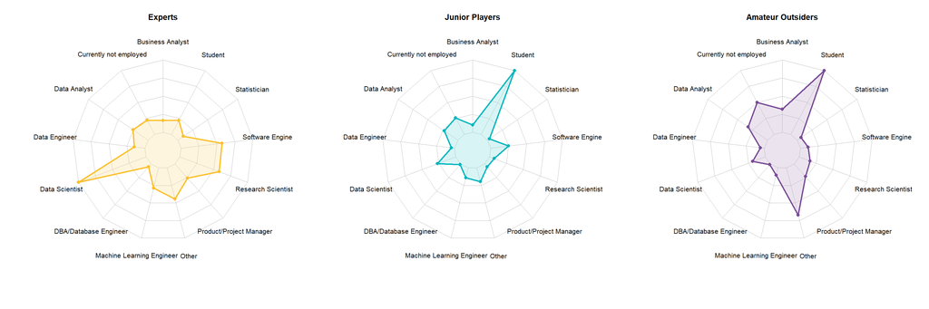

While the experts are mostly scientists, researchers, the junior team are students, or working at various positions within the data science field. The outsiders are either unemployed, not working in the field (others) or even students (they could be those pursuing a master degree or a bachelor in another field.

- Q20: What is the size of the company where you are employed?

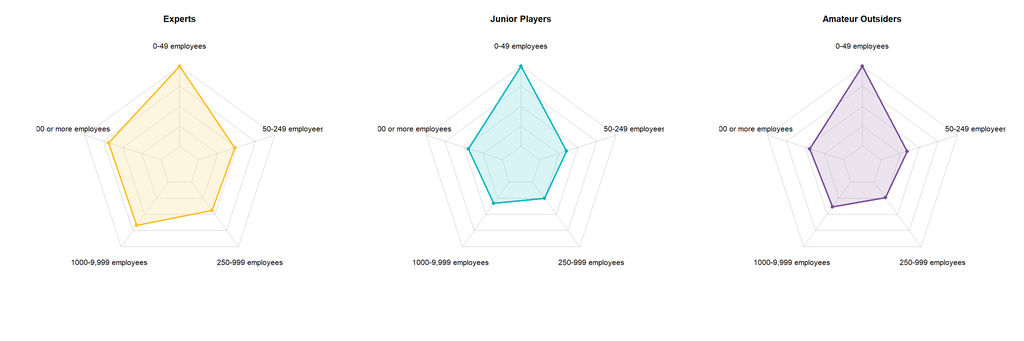

- Q21: Approximately how many individuals are responsible for data science workloads at your place at business?

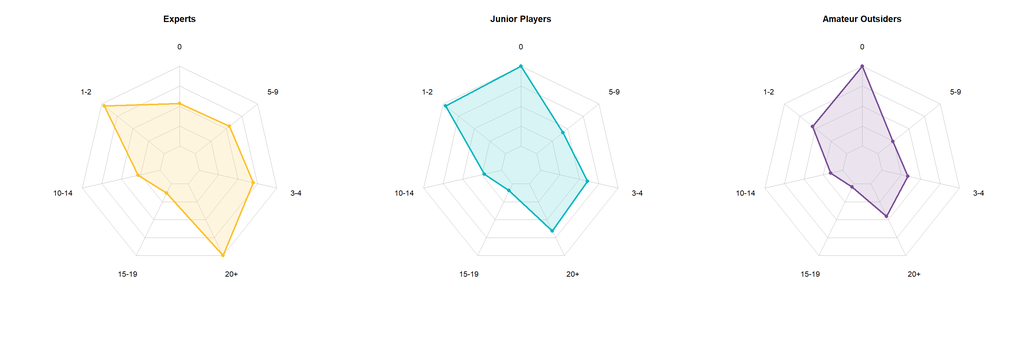

- Q22: Does your current employer incorporate machine learning methods into their business?

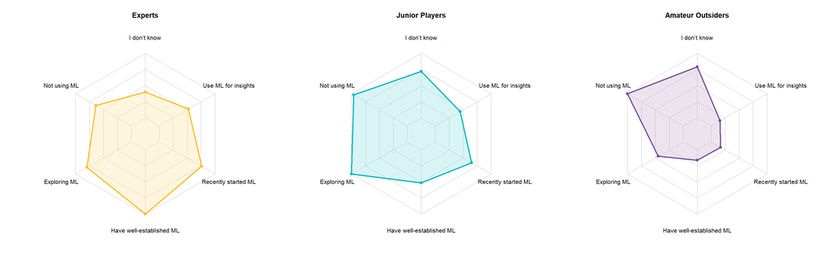

The expert team mostly work at the place where ML methods have been well established while junior peers work at the place where ML method are being explored. The outsider, however, work at the place where people do not exploit ML

- Q23: Select any activities that make up an important part of your role at work

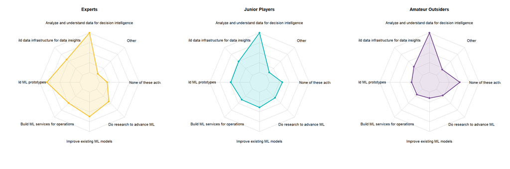

As indicated in Q5, the expert team’s jobs are mostly data scientists and researchers, therefore their work will focus more on building/running prototypes to explore applying machine learning to new areas even though they still support business decisions with their data analysis. The junior team are typical data analysts whose responsibilities mainly focus on analyzing and understand data to support business and products.

- Q24: What is your current yearly compensation (approximate $USD)?

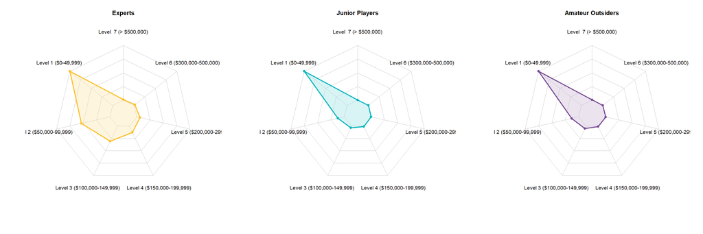

How much a data science job can bring to you? This question is always in people’s interest, especially those who just start the career or those who’re thinking about switching. According to the results in Q24, people who just join in the path will receive up to $50K, but no more than $150K. However, The compensations will increase overtime, and salary range can get bigger for the experts from 0 – $50K to $100K – $150K or even more than $200K

## Insights about technical skills

- Q7: What programming languages do you use on a regular basis?

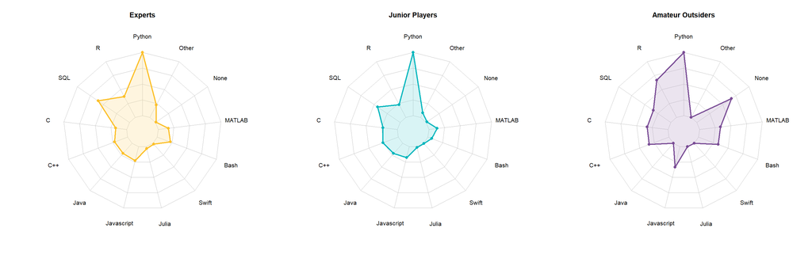

Python is the programming language that is used on a regular basis according to all groups. SQL is the second language that is used according to data science insiders (the expert & the junior). Since Python is not only capable of the statistical/modelling side of data sciencem, but also implement non-statistical functionality, it’s reasonable to stay as the most popular choice. Besides, SQL is very powerful in extracting, manipulating and loading data so it’s very common in data analytics as part of business intelligence process. It’s very interesting that, the outsiders also use R in addition to Python. This also makes sense as R is exclusively powerful for statistical analysis and modelling, it’s usually helpful for people who want to leverage their foundation of data science. Python, on the other hand, is used more for machine learning, deep learning, NLP – the more advanced side of data science.

- Q8: What programming language would you recommend an aspiring data scientist to learn first?

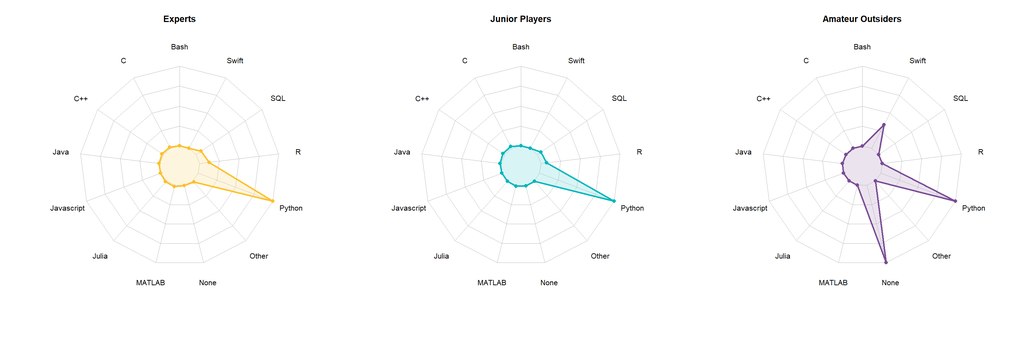

As a result of Q7, Q8 clearly indicates the language that everyone should prioritize to learn first if they would like to “communicate” in the data science world. Ideally, an individual can master other languages like SQL or R but in the long run, Python is the way to go.

- Q9: Which of the following integrated development environments (IDE’s) do you use on a regular basis?

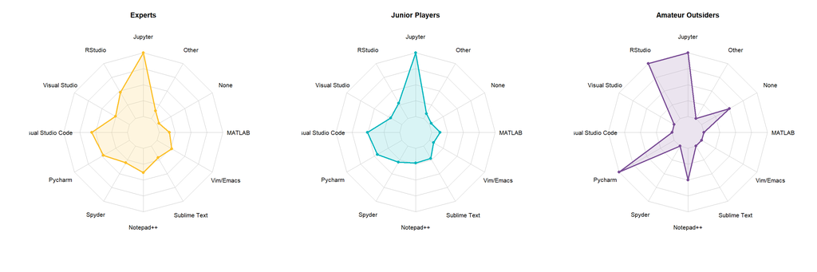

- Q14: What data visualization libraries or tools do you use on a regular basis?

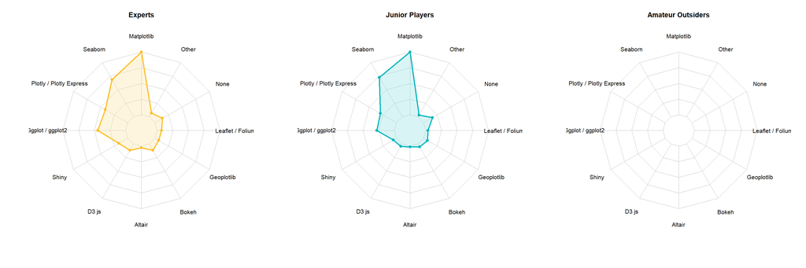

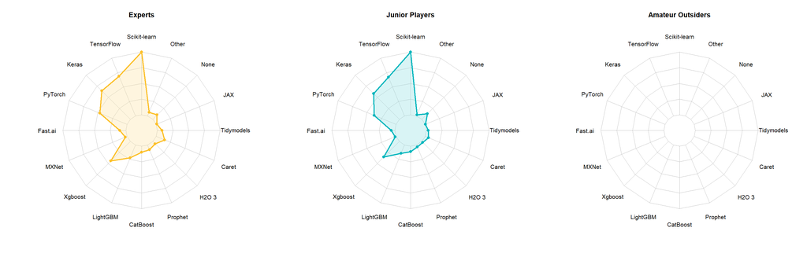

- Q29-A: Which of the following big data products (relational databases, data warehouses, data lakes, or similar) do you use on a regular basis?

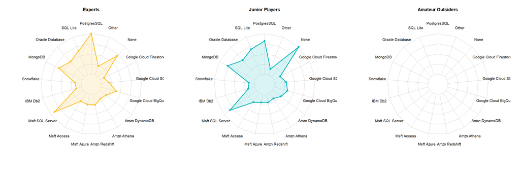

- Q31-A: Which of the following business intelligence tools do you use on a regular basis? (Select all that apply)

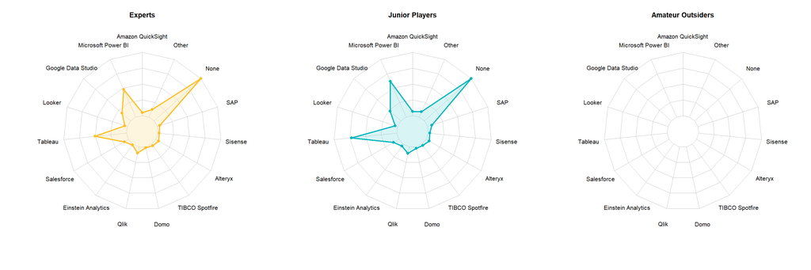

- Q36: Where do you publicly share or deploy your data analysis or machine learning applications?

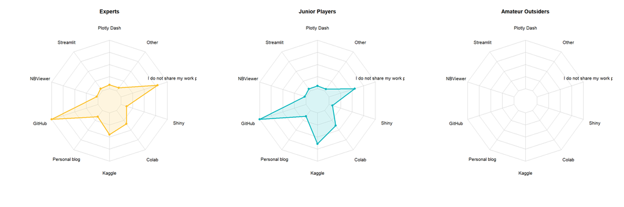

Interestingly, we don’t have any responses from the outsiders for questions related to specific tools/packages that are used in data science. The other two groups have very similar shapes, except that the experts seem to branch out to more options than the juniors. A recap of the questions is as below:

- Top visualization libraries: Matplotlib, Seaborn, ggplot2
- Top machine learning frameworks: Scikit-learn, TensorFlow, Keras
- Top big data products: PostgresSQL, MongoDB, Microsoft SQL Server
- Top BI tools: Tableau, Microsoft Power BI, Data Studio
- Top sharing/deployin platform: Github, Kaggle

Depending on which role you would like to play in data science and the level you’re at, you can prioritize the tool that’s the most popular to deep dive and master off.

One thing can be noticed from these radar charts in this section is that the junior team seems to have a strategy themselves as they are more focused on the language and IDE that they use than the other two groups. For experts, it’s possible that they want to challenge themselves and explore the efficient tools to implement their products. For outsiders, they might have been trying different things to learn more about data science and collecting clues to figure the best way to land a role here.

## Insights about learning resources

- Q37: On which platforms have you begun or completed data science courses?

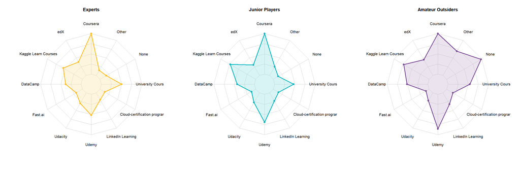

- Q38: What is the primary tool that you use at work or school to analyze data?

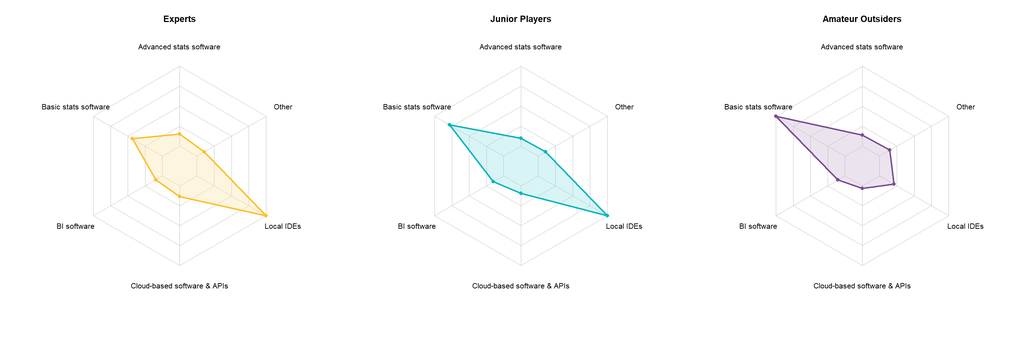

- Q39: Who/what are your favorite media sources that report on data science topics?

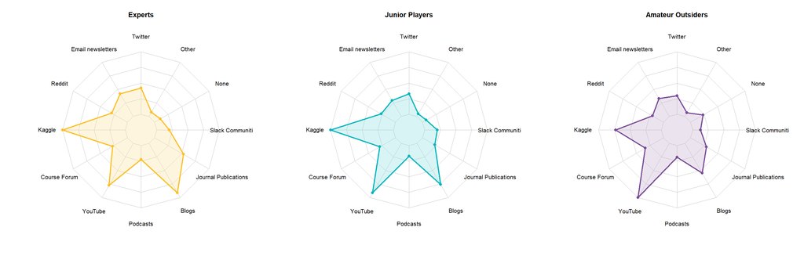